# Анализ использования транслитерации английских слов в русскоязычных онлайн-пространствах

Эркенова Джамиля

**Репозиторий в github:** https://github.com/erkenovaj/translit_analysis

**Введение** В интернет пространствах можно заметить повсеместное использование транслитерцаии. Она может быть использована в ожидаемых контекстах, например, при указании англоязычных терминов или названий. Однако часто транслитерированные выражения используются в качестве вводных слов, имея при этом распространенные аналоги на русском языке. К тому же, можно выделить набор транслитерированных выражений, которые являются заимствованиями из англоязычной интернет-культуры. Целью данной работы является исследование фразеологичности транслитерированных выражений, а также их расположения в контексте фраз.

Гипотезы: 1. Транслитерированные выражения фразеологичны, то есть есть транслитерированные выражения, которые повторяются в онлайн-пространствах чаще, чем можно считать случайным. 2. Русские слова часто подводят к транслитерированным выражениям, которые играют кульминационную роль во фразах. То есть, транслитерированные выражения статистически значимо чаще появляются в конце фразы. 3. Многословные транслитерированные выражения одинаково часто появляются в начале фраз и после существительных.

**Описание исходных данных** Данные были собраны из крупных публичных чатов различной направленности в Telegram. В том числе были рассмотрены IT-чат, чат русскоязычного сообщества англоязычных дебатов и чат фанатов Бродвея для повседневного общения. Демографию этих чатов состоавляют молодые люди 18-35 лет с хорошим знанием английского языка. Так как специфика каждого чата требует постоянного взаимодействия с англоязычными ресурсами, их участники часто включают английские выражения в свою речь.

С импользованием морфологического анализатора PyMorphy были выявлены транслитерированные выражения и части речи слов до и после них.

Размер датасета: 870 строк.

Переменные: text - Текст, translit - Транслитерированное выражение в тексте, pos_bef1 - Часть речи слова перед выражением, если слова нет - NA, pos_bef2 - Часть речи второго слова перед выражением, если слова нет - NA, pos_bef3 - Часть речи третьего слова перед выражением, если слова нет - NA, pos_aft1 - Часть речи слова после выражения, если слова нет - NA, pos_aft2 - Часть речи второго слова после выражения, если слова нет - NA, pos_aft3 - Часть речи третьего слова после выражения, если слова нет - NA.

**Описательная статистика распределений в данных и визуализации** .

```r
library(tidyverse)
data <- read_csv('final_project_data_Erkenova1.csv', locale = readr::locale(encoding = "Windows-1251"), show_col_types = FALSE)
```

```r
library(tidyr)
data = subset(data, select = -c(1) )
data <- data %>% drop_na(text, translit)
data
```

| text | translit | pos_bef1 | pos_bef2 | pos_bef3 | pos_aft1 | pos_aft2 | pos_aft3 |
| --- | --- | --- | --- | --- | --- | --- | --- |
| мы вообще друг друга не знаем дэмн | дэмн | VERB | PRCL | NOUN | NA | NA | NA |
| гоу офф ай гесс?? у кого-то очень близкая дружба | гоу офф ай гесс | NA | NA | NA | NA | PREP | NPRO |
| Нет нет ай гет ит | ай гет ит | PRED | PRED | NA | NA | NA | NA |
| энивей я тыщу лет буду монтировать видос | энивей | NA | NA | NA | NPRO | NOUN | NOUN |
| одна сатана фр | фр | NOUN | ADJF | NA | NA | NA | NA |
| в контексте виктора это плохой тейк | тейк | ADJF | PRCL | NOUN | NA | NA | NA |
| сейм я тоже сейчас вспомнила | сейм | NA | NA | NA | NPRO | PRCL | ADVB |
| энивей что я делал 6 ноября | энивей | NA | NA | NA | CONJ | NPRO | VERB |
| о дэмн | дэмн | PREP | NA | NA | NA | NA | NA |
| ахахах найс | найс | NOUN | NA | NA | NA | NA | NA |

[output cut: 837 more lines]

Посмотрим на частоту, с которой встречаются уникальные транслитерированные выражения:

```r
freq = table(data$translit)
as.data.frame(sort(freq, decreasing = TRUE))
```

| Var1 | Freq |
| --- | --- |
| лоуки | 60 |
| фр | 48 |
| ай гесс | 41 |
| сорри | 41 |
| дэмн | 35 |
| энивей | 30 |
| олсо | 29 |
| бести | 23 |
| вайб | 20 |
| би лайк | 19 |

[output cut: 305 more lines]

```r
as.data.frame(sort(prop.table(freq * 100), decreasing = TRUE))
```

| Var1 | Freq |
| --- | --- |
| лоуки | 0.070838253 |
| фр | 0.056670602 |
| ай гесс | 0.048406139 |
| сорри | 0.048406139 |
| дэмн | 0.041322314 |
| энивей | 0.035419126 |
| олсо | 0.034238489 |
| бести | 0.027154664 |
| вайб | 0.023612751 |
| би лайк | 0.022432113 |

[output cut: 305 more lines]

Можно заметить, что некоторые выражения имеют большие частоты, чем другие. Например, “лоуки” занимает 7% всех транслитерированных выражений в датасете, при том что всего имеется 315 уникальных выражений.

Рассмотрим число отсутствующих значений в датасете. Важно отметить, что NA в pos_bef1 означает, что транслитерированное выражение находится в начале фразы, а pos_aft1 - что в конце. Так, из таблицы ниже можно заметить, что транслитерированное выражение бывает в конце фразы чаще, чем в начале. В дальнейшем это утверждение будет проверено, используя статистические методы.

Из таблицы ниже видно, что почти в 60% случаях число слов слева или справа от транслитерированного выражения не превышает трех. Это связано с тем, что сообщения в чатах чаще достаточно короткие.

```r
print('Number of NaNs per column:')
```

```
[1] "Number of NaNs per column:"
```

```r
colSums(is.na(data))
```

```
    text translit pos_bef1 pos_bef2 pos_bef3 pos_aft1 pos_aft2 pos_aft3
       0        0      307      406      504      378      416      492
```

```r
504/847
```

```
[1] 0.5950413
```

```r
493/847
```

```
[1] 0.5820543
```

Посмотрим на частоту появляения различных частей речей слева и справа от транслитерированных выражений.

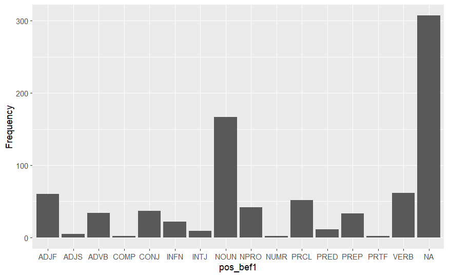

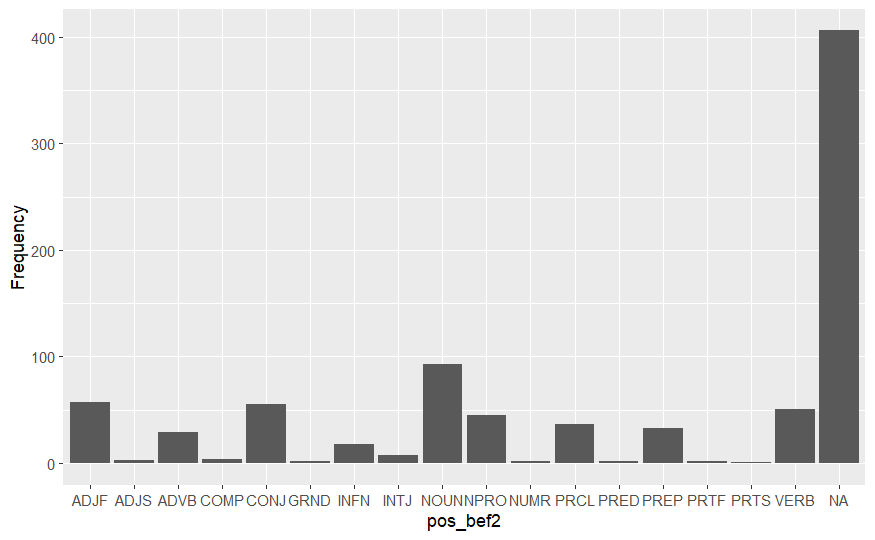

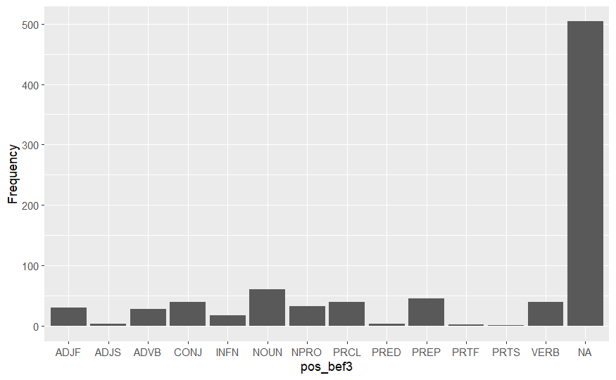

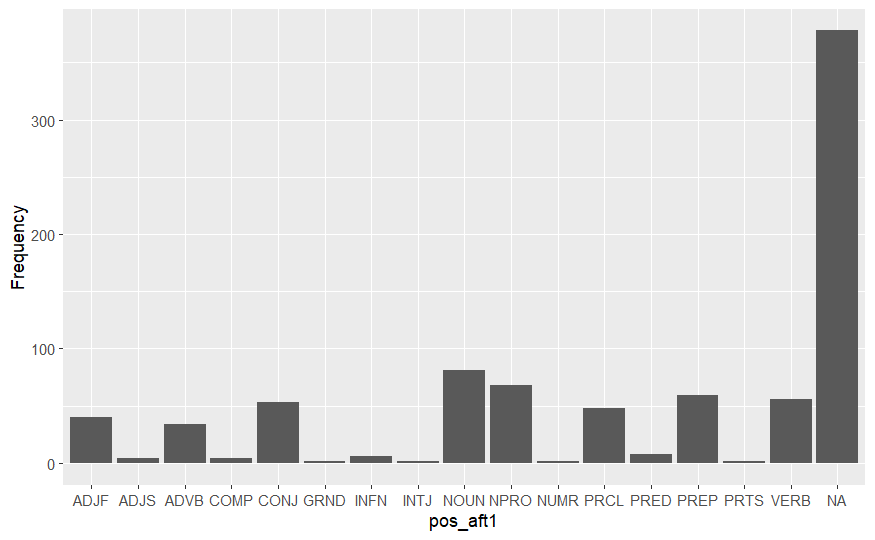

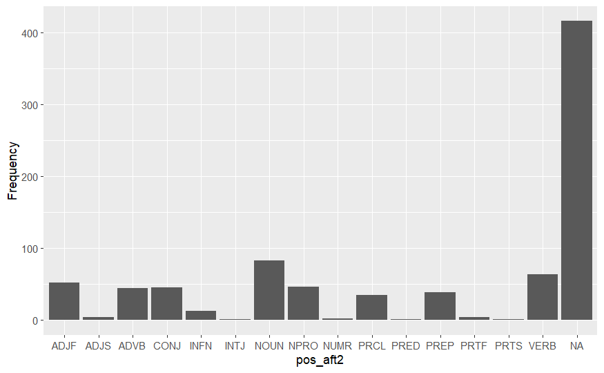

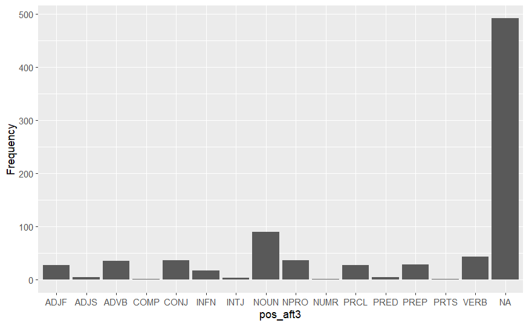

```r
pos_data = subset(data, select = -c(1, 2) )
for (i in colnames(pos_data)) {
    plot <-
      pos_data %>%
      ggplot(aes(x = .data[[i]])) + geom_bar() + labs(y = "Frequency", x = i)
    print(plot)
}
```

Чаще всего во всех позициях встречаются NA, то есть нет слов слева или справа. Это следствие коротких сообщений, транслитерированные выражения могут часто находиться в начале или конце сообщения, могут занимать большую часть фразы и не иметь больше одного-двух слов до или после.

Следующими по частоте являются имена существительные. В некоторых источниках указывается, что следующая по частоте часть речи после имени существительного - глагол. На рассматриваемом датасете данная тенденция не всегда подтверждается. Например, местоимения следуют после транслитерированных выражений чаще, чем глаголы. Это может обосновываться спецификой данных или недостаточным объемом датасета.

Выше рассматривались данные, включая транслитерированные выражения, состоящие из одного слова. Имеет смысл отдельно рассмотреть выражения, состоящие из нескольких слов, так как они с большей вероятностью могут содержать в себе самостоятельную мысль.

Ниже можно заметить, что среди длинных выражений фразеологичность менее выражена. Так, среди 266 уникальных выражений только 4 встречаются чаще, чем в 1% от всего датасета. При этом самое частое выражение “ай гесс” встречается почти в 12% всех фраз.

```r
require(stringr)
phrase_data = data[str_count(data$translit, "\\S+") >= 2, ]
phrase_data
```

| text | translit | pos_bef1 | pos_bef2 | pos_bef3 | pos_aft1 | pos_aft2 | pos_aft3 |
| --- | --- | --- | --- | --- | --- | --- | --- |
| гоу офф ай гесс?? у кого-то очень близкая дружба | гоу офф ай гесс | NA | NA | NA | NA | PREP | NPRO |
| Нет нет ай гет ит | ай гет ит | PRED | PRED | NA | NA | NA | NA |
| русреал орэндж из зе нью блэк где все точно так же но они все сидят потому что экстремистки | орэндж из зе нью блэк | NOUN | NA | NA | ADVB | PRCL | ADVB |
| до сих пор помню вы с владом зе вайтест пипл ай ноу мне без какой-либо эмоциональной окраски просто периодически всплывает в голове | зе вайтест пипл ай ноу | NOUN | PREP | NPRO | NA | NPRO | PREP |
| но еще это такой лоуки лавбомбинг теперь мне еще тяжелее стать достаточно злой | лоуки лавбомбинг | ADJF | PRCL | ADVB | ADVB | NPRO | ADVB |
| если я причиняла кому-то реальный физический вред мне хотелось сдохнуть но ю ду ю | ю ду ю | CONJ | INFN | VERB | NA | NA | NA |
| КТО-ТО ПОПРОСИЛ ИХ ПРЕПОДШУ ПЕРЕВЕСТИ кэн ю блоу май висл | кэн ю блоу май висл | NA | INFN | NOUN | NA | NA | NA |
| а ну да ай донт рилли ду рис?рч ЧТО??? | ай донт рилли ду рис?рч | PRCL | PRCL | CONJ | NA | CONJ | NA |
| там основная мысль сюжета понятна и без глубоко анализа ай гесс но хз мне вот щас надо посидеть обмозговать я не все штуки поняла | ай гесс | NOUN | ADVB | PREP | NPRO | PRCL | ADVB |
| я проучилась 15 лет думая что люди общаются со мной только потому что я могу помочь по учебе итс Бэд фор ми | итс Бэд фор ми | NOUN | PREP | INFN | NA | NA | NA |

[output cut: 339 more lines]

```r
as.data.frame(sort(table(phrase_data$translit), decreasing = TRUE))
```

| Var1 | Freq |
| --- | --- |
| ай гесс | 41 |
| би лайк | 19 |
| самфинг самфинг | 5 |
| эт зис поинт | 5 |
| айлл тейк ит | 3 |
| иф зет хелпс | 3 |
| майнд геймс | 3 |
| хоуп зет хелпс | 3 |
| эт сам поинт | 3 |
| ю ду ю | 3 |

[output cut: 256 more lines]

```r
as.data.frame(sort(prop.table(table(phrase_data$translit) * 100), decreasing = TRUE))
```

| Var1 | Freq |
| --- | --- |
| ай гесс | 0.117478510 |
| би лайк | 0.054441261 |
| самфинг самфинг | 0.014326648 |
| эт зис поинт | 0.014326648 |
| айлл тейк ит | 0.008595989 |
| иф зет хелпс | 0.008595989 |
| майнд геймс | 0.008595989 |
| хоуп зет хелпс | 0.008595989 |
| эт сам поинт | 0.008595989 |
| ю ду ю | 0.008595989 |

[output cut: 256 more lines]

Посмотрим на частоту появления частей речи в различных позициях для транслитерированных выражений, состоящих из нескольких слов.

Ниже можно заметить, что подобные выражения появляются после существительных довольно часто. Можно предположить, что это происходит с той же вероятностью, с которой многословное транслитерированное выражение находится в начале фразы. Данное утверждение будет проверено дальше.

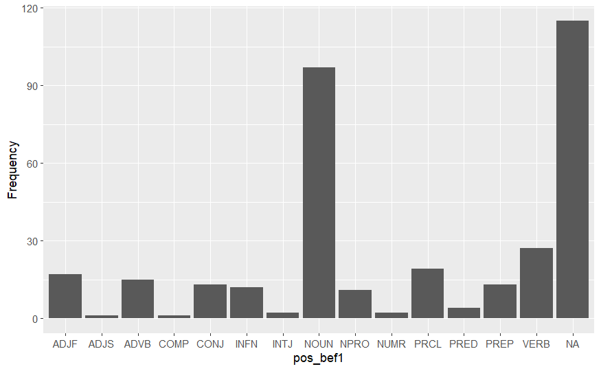

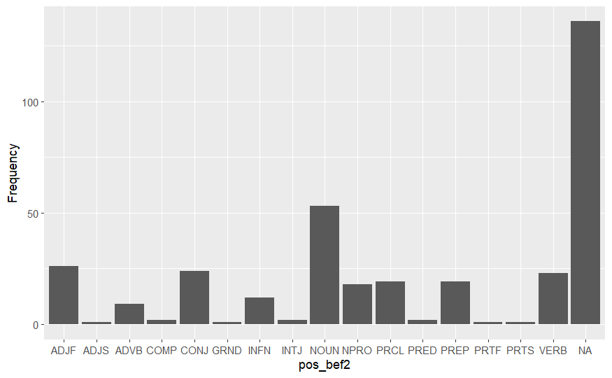

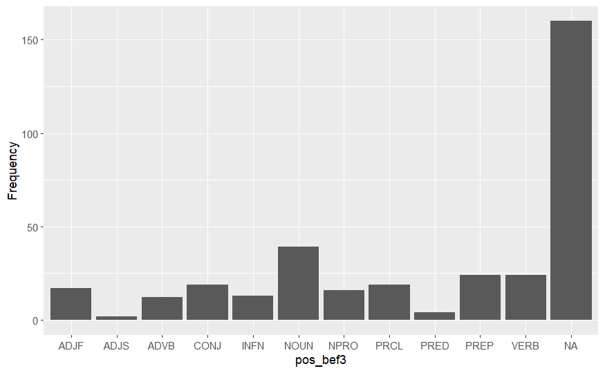

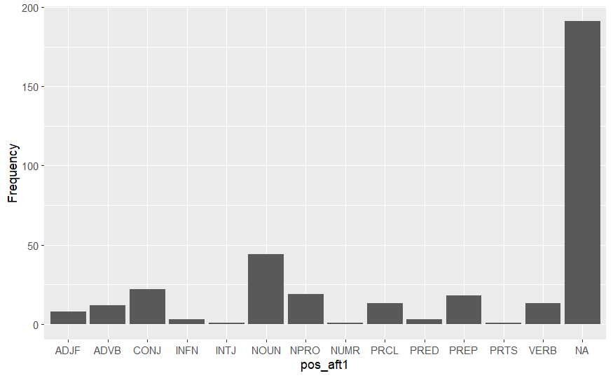

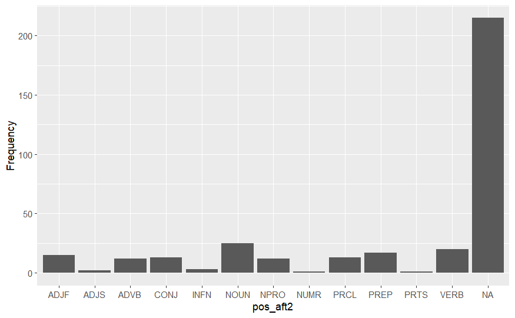

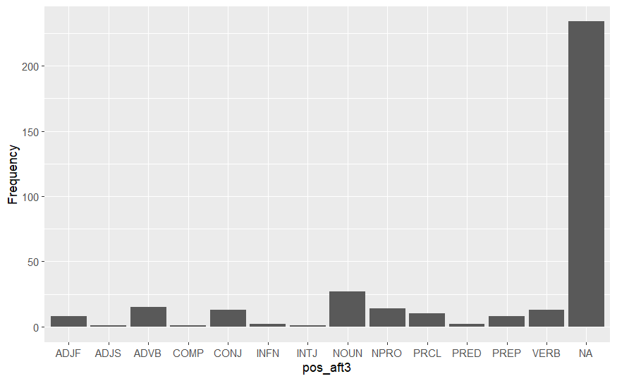

```r
phrase_pos_data <- subset(phrase_data, select = -c(1, 2) )
for (i in colnames(phrase_pos_data)) {
    plot <-
      phrase_pos_data %>%
      ggplot(aes(x = .data[[i]])) + geom_bar() + labs(y = "Frequency", x = i)
    print(plot)
}
```

В ходе анализа были выявлены некоторые гипотезы. Далее рассматриваются возможные подходы к их оценкам.

Первая поставленная гипотеза заключалась во фразеологичности выражений. В целом, она подтверждается частотой, с которой встречаются некоторые выражения. Но для того, чтобы убедиться в правильности вывода, можно провести определенные тесты.

H0: Есть транслитерированные выражения, которые повторяются в онлайн-пространствах чаще, чем можно считать случайным. H1: Нет транслитерированных выражений, которые повторяются в онлайн-пространствах чаще, чем можно считать случайным

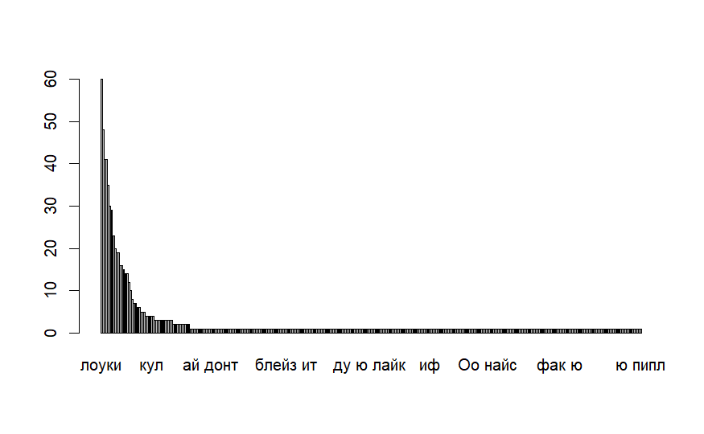

```r
barplot(sort(freq, decreasing = TRUE))
```

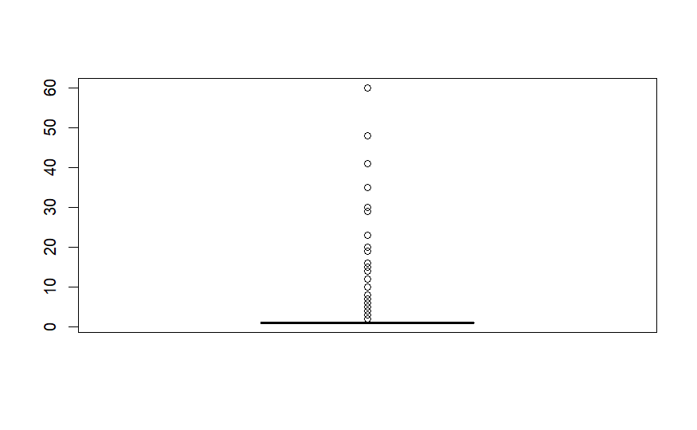

```r
boxplot(freq)
```

На графике “ящик с усами” можно заметить, что в данных представлено много выбросов из общего распределения. Из 315 выражений 42 превысили это значение. Можно предположить, что эти 42 выражения появляются чаще, чем ожидается. Лингвистически это можно интерпретировать как фрезологичность этих выражений.

Интересно попробовать смоделировать частоту появляения выражения на основе вероятности появляения той или иной части речи в каждой позиции до и после транслитерированного выражения.

Создадим дамми-переменную для каждой части речи в каждой позиции, подсчитаем веряотности их появления и присоединим к получившемуся датасету частоты появления каждого транслитерированног выражения. Таким образом получим датасет, имеющий 99 столбцов. Важно учесть, что довольно часто вероятности равняются 0, что скорее всего связано с небольшим объемом данных, но может объясняться и характером появляения конкретного транслитерированного выражения.

```r
library(dplyr)
library(fastDummies)
data_dumm <- data %>%
   mutate_all(~replace(., is.na(.), 0))
data_dumm <- subset(data_dumm, select = -c(1) )
data_dumm <- subset(fastDummies::dummy_cols(data_dumm, select_columns = c("pos_bef1", "pos_bef2", "pos_bef3", "pos_aft1", "pos_aft2", "pos_aft3")),
select = -c(2, 3, 4, 5, 6, 7))

#data_dumm <- replace(data_dumm, is.na(data_dumm), 0)

data_dumm <- data_dumm %>%
group_by(translit) %>%
summarise(across(everything(), mean))
data_dumm <- data_dumm[-c(1, 2, 3, 4), ]

freq_df = as.data.frame(sort(prop.table(freq), decreasing = TRUE))
names(freq_df)[names(freq_df) == 'Var1'] <- 'translit'
data_dumm <- merge(x = data_dumm, y = freq_df, by = "translit", all.x = TRUE)
data_dumm
```

| translit | pos_bef1_0 | pos_bef1_ADJF | pos_bef1_ADJS | pos_bef1_ADVB | pos_bef1_COMP | pos_bef1_CONJ | pos_bef1_INFN | pos_bef1_INTJ | pos_bef1_NOUN | pos_bef1_NPRO | pos_bef1_NUMR | pos_bef1_PRCL | pos_bef1_PRED | pos_bef1_PREP | pos_bef1_PRTF | pos_bef1_VERB | pos_bef2_0 | pos_bef2_ADJF | pos_bef2_ADJS | pos_bef2_ADVB | pos_bef2_COMP | pos_bef2_CONJ | pos_bef2_GRND | pos_bef2_INFN | pos_bef2_INTJ | pos_bef2_NOUN | pos_bef2_NPRO | pos_bef2_NUMR | pos_bef2_PRCL | … |
| --- | --- | --- | --- | --- | --- | --- | --- | --- | --- | --- | --- | --- | --- | --- | --- | --- | --- | --- | --- | --- | --- | --- | --- | --- | --- | --- | --- | --- | --- | --- |
| авередж стрейт вайт мейл тиви райтер тм | 0.00000000 | 0.00000000 | 0.00000000 | 0.00000000 | 0.000 | 0.00000000 | 0.00000000 | 1.00000000 | 0.00000000 | 0.00000000 | 0 | 0.00000000 | 0.00000000 | 0.00000000 | 0.00000000 | 0.00000000 | 0.0000000 | 0.00000000 | 0.00000000 | 0.00000000 | 0.000 | 0.00000000 | 0.00000000 | 0.00000000 | 0.00000000 | 1.00000000 | 0.00000000 | 0.00000000 | 0.00000000 | … |
| азер пипл | 1.00000000 | 0.00000000 | 0.00000000 | 0.00000000 | 0.000 | 0.00000000 | 0.00000000 | 0.00000000 | 0.00000000 | 0.00000000 | 0 | 0.00000000 | 0.00000000 | 0.00000000 | 0.00000000 | 0.00000000 | 1.0000000 | 0.00000000 | 0.00000000 | 0.00000000 | 0.000 | 0.00000000 | 0.00000000 | 0.00000000 | 0.00000000 | 0.00000000 | 0.00000000 | 0.00000000 | 0.00000000 | … |
| ай вилл олвейс лав ю | 0.00000000 | 0.00000000 | 0.00000000 | 0.00000000 | 0.000 | 0.00000000 | 0.00000000 | 0.00000000 | 0.00000000 | 0.00000000 | 0 | 0.00000000 | 0.00000000 | 0.00000000 | 0.00000000 | 1.00000000 | 0.0000000 | 0.00000000 | 0.00000000 | 0.00000000 | 0.000 | 0.00000000 | 0.00000000 | 0.00000000 | 0.00000000 | 1.00000000 | 0.00000000 | 0.00000000 | 0.00000000 | … |
| ай виш | 0.00000000 | 0.00000000 | 0.00000000 | 0.00000000 | 0.000 | 0.00000000 | 0.00000000 | 0.00000000 | 1.00000000 | 0.00000000 | 0 | 0.00000000 | 0.00000000 | 0.00000000 | 0.00000000 | 0.00000000 | 1.0000000 | 0.00000000 | 0.00000000 | 0.00000000 | 0.000 | 0.00000000 | 0.00000000 | 0.00000000 | 0.00000000 | 0.00000000 | 0.00000000 | 0.00000000 | 0.00000000 | … |
| ай виш ай хэд | 0.00000000 | 0.00000000 | 0.00000000 | 0.00000000 | 0.000 | 0.00000000 | 0.00000000 | 0.00000000 | 0.00000000 | 0.00000000 | 0 | 0.00000000 | 0.00000000 | 0.00000000 | 0.00000000 | 1.00000000 | 0.0000000 | 0.00000000 | 0.00000000 | 0.00000000 | 0.000 | 0.00000000 | 0.00000000 | 0.00000000 | 0.00000000 | 0.00000000 | 1.00000000 | 0.00000000 | 0.00000000 | … |
| ай гейв ю э ютиай | 0.00000000 | 0.00000000 | 0.00000000 | 0.00000000 | 0.000 | 0.00000000 | 1.00000000 | 0.00000000 | 0.00000000 | 0.00000000 | 0 | 0.00000000 | 0.00000000 | 0.00000000 | 0.00000000 | 0.00000000 | 0.0000000 | 0.00000000 | 0.00000000 | 0.00000000 | 0.000 | 0.00000000 | 0.00000000 | 0.00000000 | 0.00000000 | 0.00000000 | 0.00000000 | 0.00000000 | 0.00000000 | … |
| ай гесс | 0.53658537 | 0.07317073 | 0.00000000 | 0.02439024 | 0.000 | 0.00000000 | 0.04878049 | 0.00000000 | 0.17073171 | 0.04878049 | 0 | 0.02439024 | 0.04878049 | 0.00000000 | 0.00000000 | 0.02439024 | 0.6097561 | 0.00000000 | 0.00000000 | 0.07317073 | 0.000 | 0.00000000 | 0.02439024 | 0.02439024 | 0.00000000 | 0.09756098 | 0.02439024 | 0.00000000 | 0.02439024 | … |
| ай гет ит | 0.00000000 | 0.00000000 | 0.00000000 | 0.00000000 | 0.000 | 0.50000000 | 0.00000000 | 0.00000000 | 0.00000000 | 0.00000000 | 0 | 0.00000000 | 0.50000000 | 0.00000000 | 0.00000000 | 0.00000000 | 0.0000000 | 0.00000000 | 0.00000000 | 0.00000000 | 0.000 | 0.00000000 | 0.00000000 | 0.00000000 | 0.00000000 | 0.50000000 | 0.00000000 | 0.00000000 | 0.00000000 | … |
| ай гет ИТ ай гет | 0.00000000 | 0.00000000 | 0.00000000 | 0.00000000 | 0.000 | 0.00000000 | 0.00000000 | 0.00000000 | 1.00000000 | 0.00000000 | 0 | 0.00000000 | 0.00000000 | 0.00000000 | 0.00000000 | 0.00000000 | 0.0000000 | 0.00000000 | 0.00000000 | 0.00000000 | 0.000 | 0.00000000 | 0.00000000 | 0.00000000 | 0.00000000 | 0.00000000 | 0.00000000 | 0.00000000 | 0.00000000 | … |
| ай дез?рв зет | 0.00000000 | 0.00000000 | 0.00000000 | 0.00000000 | 0.000 | 0.00000000 | 0.00000000 | 0.00000000 | 1.00000000 | 0.00000000 | 0 | 0.00000000 | 0.00000000 | 0.00000000 | 0.00000000 | 0.00000000 | 0.0000000 | 1.00000000 | 0.00000000 | 0.00000000 | 0.000 | 0.00000000 | 0.00000000 | 0.00000000 | 0.00000000 | 0.00000000 | 0.00000000 | 0.00000000 | 0.00000000 | … |

[output cut: 301 more lines]

```r
test <- glm(Freq ~ ., family = binomial(), data = subset(data_dumm, select = -c(1)))
summary(test)
```

```
Call:
glm(formula = Freq ~ ., family = binomial(), data = subset(data_dumm,
    select = -c(1)))

Coefficients: (9 not defined because of singularities)
                Estimate Std. Error z value Pr(>|z|)
(Intercept)    -5.665908  19.955999  -0.284    0.776
pos_bef1_0     -0.069179   6.803198  -0.010    0.992
pos_bef1_ADJF   0.059416   8.213083   0.007    0.994
pos_bef1_ADJS   0.368152  16.754717   0.022    0.982
pos_bef1_ADVB  -0.494853   9.683159  -0.051    0.959
pos_bef1_COMP   0.508392  28.603072   0.018    0.986
pos_bef1_CONJ  -0.068891  10.431819  -0.007    0.995
pos_bef1_INFN  -0.250862  10.358242  -0.024    0.981
pos_bef1_INTJ   0.310270  13.449154   0.023    0.982
pos_bef1_NOUN  -0.246769   6.946829  -0.036    0.972
pos_bef1_NPRO  -0.085746  10.810251  -0.008    0.994
pos_bef1_NUMR  -0.683349  25.401114  -0.027    0.979
pos_bef1_PRCL  -0.005942   8.072192  -0.001    0.999
pos_bef1_PRED  -0.361732  24.841841  -0.015    0.988
pos_bef1_PREP  -0.223759   9.630122  -0.023    0.981
pos_bef1_PRTF  43.301788 119.854847   0.361    0.718
pos_bef1_VERB         NA         NA      NA       NA
pos_bef2_0     -0.178785   7.902303  -0.023    0.982
pos_bef2_ADJF   0.169118   9.016705   0.019    0.985
pos_bef2_ADJS   2.847548  30.512761   0.093    0.926
pos_bef2_ADVB   0.608174  11.019545   0.055    0.956
pos_bef2_COMP  -0.043310  22.464508  -0.002    0.998
pos_bef2_CONJ  -0.325293   8.847007  -0.037    0.971
pos_bef2_GRND   2.848431  68.035306   0.042    0.967
pos_bef2_INFN  -0.440950  11.533792  -0.038    0.970
pos_bef2_INTJ  -0.218761  16.158432  -0.014    0.989
pos_bef2_NOUN  -0.097739   8.231969  -0.012    0.991
pos_bef2_NPRO  -0.383296   9.850405  -0.039    0.969
pos_bef2_NUMR 162.012145 262.200286   0.618    0.537
pos_bef2_PRCL  -0.206596  10.100453  -0.020    0.984
pos_bef2_PRED   0.089753  49.238208   0.002    0.999
pos_bef2_PREP  -0.192907  10.168100  -0.019    0.985
pos_bef2_PRTF  -1.524705  57.731561  -0.026    0.979
pos_bef2_PRTS  -0.364956  32.032989  -0.011    0.991
```

[output cut: 57 more lines]

```
pos_aft3_NPRO  -0.400258  12.884544  -0.031    0.975
pos_aft3_NUMR         NA         NA      NA       NA
pos_aft3_PRCL   0.443147  12.771299   0.035    0.972
pos_aft3_PRED   1.433055  47.059240   0.030    0.976
pos_aft3_PREP  -0.350919  13.170940  -0.027    0.979
pos_aft3_PRTS         NA         NA      NA       NA
pos_aft3_VERB         NA         NA      NA       NA

(Dispersion parameter for binomial family taken to be 1)

    Null deviance: 2.11674  on 310  degrees of freedom
Residual deviance: 0.72639  on 222  degrees of freedom
AIC: 180

Number of Fisher Scoring iterations: 14
```

Следующая упомянутая гипотеза: H0: Транслитерированные выражения статистически значимо чаще появляются в конце фразы. H1: Транслитерированные выражения статистически значимо чаще появляются в начале или середине фразы.

Для начала оценим, как часто транслитерированные выражения появляются в конце фразы и как часто в начале или середине. Из графика можно заметить, что они появляются в конце немного чаще. Оценим относительные частоты. Транслитерированные выражения действительно появляются в конце фразы чаще, при этом разница в вероятностях составляет около 3%.

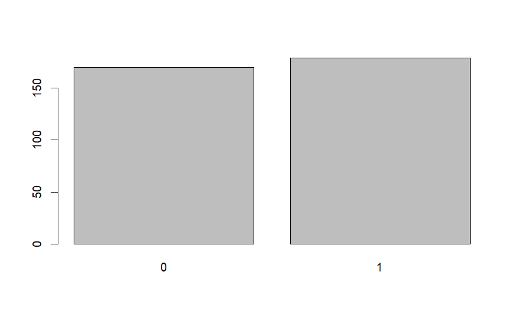

```r
phrase_data$is_end <- ifelse(is.na(phrase_data$pos_aft1) & is.na(phrase_data$pos_aft2) & is.na(phrase_data$pos_aft3), 1, 0)
barplot(table(phrase_data$is_end))
```

```r
prop.table(table(phrase_data$is_end))
```

```
       0        1
0.487106 0.512894
```

Следующая гипотеза: H0: Транслитерированные выражения из нескольких слов с одинаковой вероятностью могут стоять в начале предложения или после существительного. H1: Транслитерированные выражения из нескольких слов с меньшей вероятностью могут стоять в начале предложения, чем после существительного.

Визуализируем данные для данной гипотезы. Визуально можно заметить, что два распределения схожи. Используем тест Колмогорова-Смирнова для того, чтобы убедиться в этом.

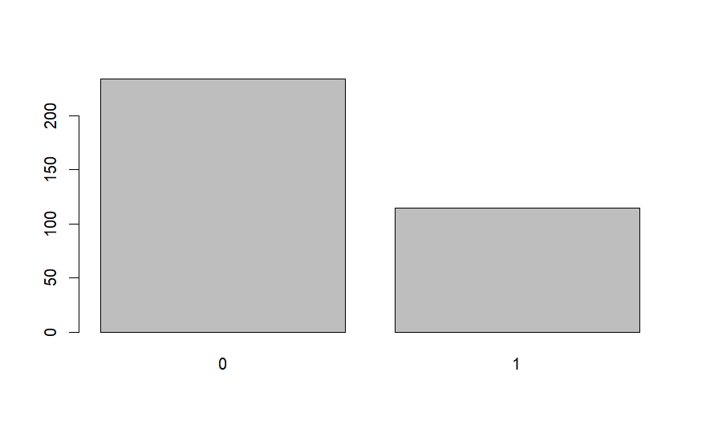

```r
phrase_data$is_start <- ifelse(is.na(phrase_data$pos_bef1), 1, 0)

phrase_data$is_after_noun <- ifelse((phrase_data$pos_bef1 == 'NOUN'), 1, 0)

barplot(table(phrase_data$is_start))
```

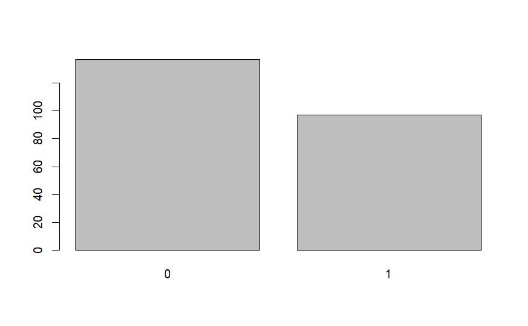

```r
barplot(table(phrase_data$is_after_noun))
```

```r
ks.test(phrase_data$is_start, phrase_data$is_after_noun)
```

```
    Asymptotic two-sample Kolmogorov-Smirnov test

data:  phrase_data$is_start and phrase_data$is_after_noun
D = 0.085017, p-value = 0.2634
alternative hypothesis: two-sided
```

Так как p-value > 0.05 нулевая гипотеза принимается, то есть распределения появляения транслитерированных выражений в начале и после существительных схожи.

**Выводы**

Для оценки данных рассматриваемых гипотез часто был достаточным визуальный и количественный анализ, ввиду простоты рассматриваемых данных. Различные методы визуального отображения позволяют обратить внимание на разные характеристики данных. Так, гистограмма позволила увидеть распределение частот транслитерированных выражений, а ящик с ума более наглядно показал большое число выбросов.

Для проверки последней гипотезы использовалось два метода: визуальный анализ и тест Колмогорова-Смирнова. По отдельности оба метода не являются достаточно показательными, но вместе они позволяют и оценить гипотезу визуально, и подтвердить ее статистически.

Более сложным оказался подбор методов для оценки второй гипотезы. Сложность заключалась в простоте имеющихся данных и недостатке негативных данных. Ввиду данных ограничений не представлялось возможным доказать гипотезу иначе как сравнив значения вероятностей и визуально оценив распределение.

Другой проведенный анализ состоял в оценки влияния нахождения всех частей речи в разных позициях до и после транслитерированного выражения на частоту появления выражения. Путем построения логистической регрессии было выявлено, что влияния как такового нет.

Другие работы о транслитерации рассматривают различные явления, многие из них посвящены переводу. Также есть статья, исследующая влияние транслитерации на читаемость[1]. Не удалось найти исследования, имеющие те же цели, что и данное, поэтому сравнение результатов не представляется возможным. Тем не менее, существуют схожие исследования, касающиеся других лингвистических явлений, например сленга[2]. В исследовании проводится статистический анализ использования сленгов в речи школьников, основанный на данных анкетирования школьников.

**Список литературы:**

1. Sambhav Jain, Kunal Sachdeva & Ankush Soni, Effect of Transliteration on Readability, 2013, URL: https://link.springer.com/chapter/10.1007/978-3-642-39360-0_6
2. Попелышко Владислава, Употребление сленга в речи школьников и способы его искоренения, 2017, URL: https://nsportal.ru/ap/library/drugoe/2017/02/26/nauchnaya-rabota-upotreblenie-slenga-v-rechi-shkolnikov-i-sposoby-ego